# Data Dive - Probabilities and Anomalies

Amritha Prakash

2023-09-14

## ASSIGNMENT 3

### **Read the Data**

```r
# Load tidyverse
library(tidyverse)
library(dplyr)

Superstore_data=read.csv("SampleSuperstore_final.csv")
head(Superstore_data)
```

```
##        Ship.Mode   Segment       Country            City      State Postal.Code
## 1   Second Class  Consumer United States       Henderson   Kentucky       42420
## 2   Second Class  Consumer United States       Henderson   Kentucky       42420
## 3   Second Class Corporate United States     Los Angeles California       90036
## 4 Standard Class  Consumer United States Fort Lauderdale    Florida       33311
## 5 Standard Class  Consumer United States Fort Lauderdale    Florida       33311
## 6 Standard Class  Consumer United States     Los Angeles California       90032
##   Region        Category Sub.Category    Sales Quantity Discount    Profit
## 1  South       Furniture    Bookcases 261.9600        2     0.00   41.9136
## 2  South       Furniture       Chairs 731.9400        3     0.00  219.5820
## 3   West Office Supplies       Labels  14.6200        2     0.00    6.8714
## 4  South       Furniture       Tables 957.5775        5     0.45 -383.0310
## 5  South Office Supplies      Storage  22.3680        2     0.20    2.5164
## 6   West       Furniture  Furnishings  48.8600        7     0.00   14.1694
```

QUESTION

1. At least 3 “group by” data frames, and an investigation into each. You’ll need to use categorical columns, or one of the cut_ functions here.
- Use the group_by function to group your data into (at least) 3 different sets of groups, each summarizing different variables.
- For example, this could be as simple as three data frames which group your data based on three different categorical columns, but summarize the same continuous column. Or, it could be as complex as three different combinations of categorical columns, each illustrating summarizations of different continuous (or categorical columns).
- Within each group_by data frame, calculate the expected probability for each group. Maybe assign the lowest probability group an “anomaly” tag, and then translate that back into your original data frame. Draw some conclusions about the numbers you’ve calculated.
- Try to draw a testable hypothesis for why some groups are rarer than others (How might you test this hypothesis?)
- Think of different ways to visualize these groups

### 1.Segment :-

- Expected Probability - Segment

```r
total_records <- nrow(Superstore_data)
#total_records



# 1 group_by Segment and expected probability for Segment

Segment_group <- Superstore_data |>
  group_by(Segment) |>
  summarise(total_count_segment=n(),
            .groups = 'drop') |>
  mutate(Expected_probability_Segment= (total_count_segment/total_records)) #|>
  #mutate(Segment_Spl_tag = case_When(Expected_probability_Segment>0.519  ~ 'Usual'),)

Segment_group
```

```
## # A tibble: 3 × 3
##   Segment     total_count_segment Expected_probability_Segment
##   <chr>                     <int>                        <dbl>
## 1 Consumer                   5191                        0.519
## 2 Corporate                  3020                        0.302
## 3 Home Office                1783                        0.178
```

```r
merged_data <- merge(Superstore_data, Segment_group, by = "Segment", all.x = TRUE)

# Define a function to calculate 'Segment_Special_tag'
Segment_Special_tag <- function(total_count_segment) {
  if (total_count_segment >= 3020) {
    return("normal")
  }else {
    return("low")
  }
}

# Apply the function to create 'Segment_anomaly' column
merged_data$Segment_Special_tag <- sapply(merged_data$total_count_segment, Segment_Special_tag)


# Print the resulting table
print(merged_data|> select("Segment","Expected_probability_Segment","Segment_Special_tag")|> sample_n(10) )
```

```
##        Segment Expected_probability_Segment Segment_Special_tag
## 1    Corporate                    0.3021813              normal
## 2    Corporate                    0.3021813              normal
## 3  Home Office                    0.1784070                 low
## 4     Consumer                    0.5194116              normal
## 5     Consumer                    0.5194116              normal
## 6     Consumer                    0.5194116              normal
## 7    Corporate                    0.3021813              normal
## 8     Consumer                    0.5194116              normal
## 9  Home Office                    0.1784070                 low
## 10    Consumer                    0.5194116              normal
```

Observations -

- 0.519 is the probability of records in the dataset that have the Segment- Consumer, while the probability of records for corporate and Home office are 0.302 and 0.1783 respectively.
- Consumer Segment is seen to be a significant one when it comes to the products bought i.e. Most records are of consumer segment.

### - To check if we pull a row/data randomly, then which one segment would we observe

#1.

```r
sample1 <- sample_n(merged_data,1)
sample1 |> select("Segment","Expected_probability_Segment","Segment_Special_tag")
```

```
##     Segment Expected_probability_Segment Segment_Special_tag
## 1 Corporate                    0.3021813              normal
```

From above, can see that the data pulled randomly

#2.

```r
sample2 <- sample_n(merged_data,1)
sample2 |> select("Segment","Expected_probability_Segment","Segment_Special_tag")
```

```
##    Segment Expected_probability_Segment Segment_Special_tag
## 1 Consumer                    0.5194116              normal
```

From above,again can see that the data pulled randomly.

#3.

```r
sample3 <- sample_n(merged_data,1)
sample3 |> select("Segment","Expected_probability_Segment","Segment_Special_tag")
```

```
##    Segment Expected_probability_Segment Segment_Special_tag
## 1 Consumer                    0.5194116              normal
```

#4.

```r
sample3 <- sample_n(merged_data,1)
sample3 |> select("Segment","Expected_probability_Segment","Segment_Special_tag")
```

```
##    Segment Expected_probability_Segment Segment_Special_tag
## 1 Consumer                    0.5194116              normal
```

In all those random pulls the Home office must have appeared or not in segments , like very rare. Consumer segments have higher probability in being taken out.

## Visualize Segments Group-

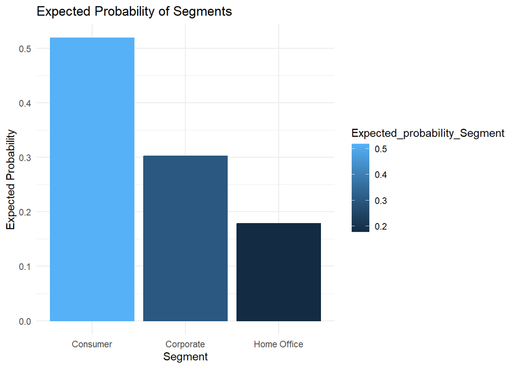

```r
Segment_group |>
  ggplot(mapping = aes(x=Segment, y = Expected_probability_Segment, color=Expected_probability_Segment, fill=Expected_probability_Segment)) +
  geom_bar(stat = "identity") +
  labs(
    title = "Expected Probability of Segments",
    x = "Segment",
    y = "Expected Probability"
  ) +
  theme_minimal()
```

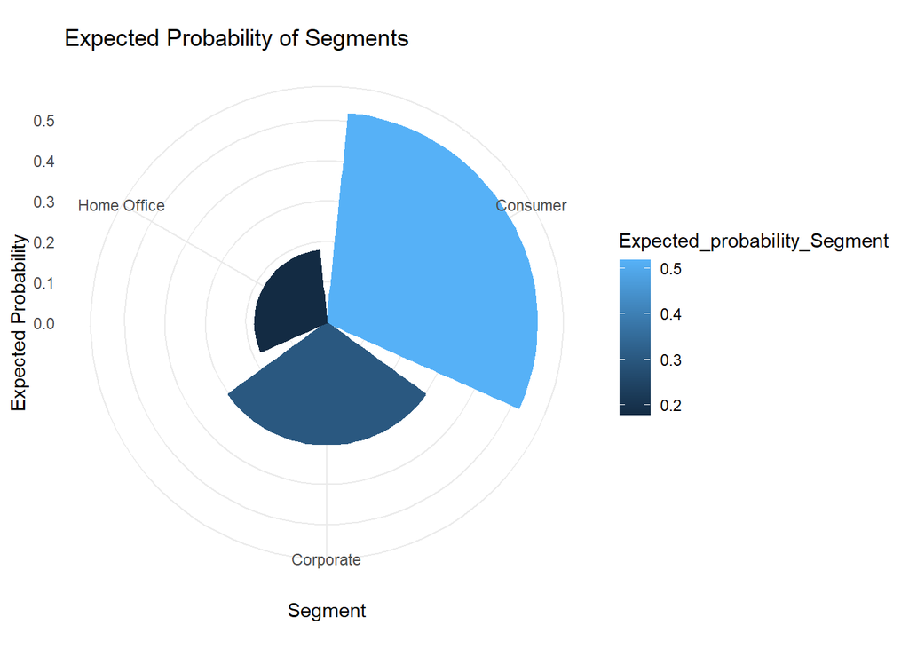

```r
last_plot() +
  coord_polar()
```

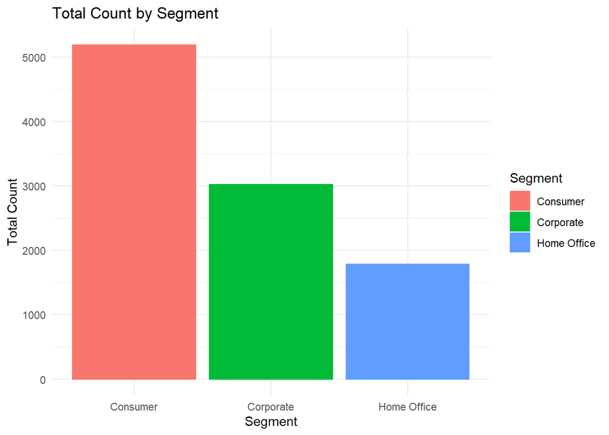

```r
Superstore_data |>
  ggplot(mapping = aes(x=Segment, color=Segment, fill=Segment)) +
  geom_bar() +
  labs(
    title = "Total Count by Segment",
    x = "Segment",
    y = "Total Count"
  ) +
  theme_minimal()
```

From the above plots, we can see that the visualizations also state that most records are of Consumer segment with highest product purchase. Least bought items are from the Home Office segment. The reason for Home Office to show least could be that the products purchased for that are least in the entire Country.

### 2.Region -

- Expected Probability - Region :

```r
# 2 group_by Region
Region_group <- Superstore_data |>
  group_by(Region) |>
  summarise(total_count_region=n(),
            .groups = 'drop') |>
  mutate(Expected_probability_Region= (total_count_region/total_records))

Region_group
```

```
## # A tibble: 4 × 3
##   Region  total_count_region Expected_probability_Region
##   <chr>                <int>                       <dbl>
## 1 Central               2323                       0.232
## 2 East                  2848                       0.285
## 3 South                 1620                       0.162
## 4 West                  3203                       0.320
```

```r
merged_data <- merge(Superstore_data, Region_group, by = "Region", all.x = TRUE)

# Define a function to calculate 'Segment_Special_tag'
Region_Special_tag <- function(total_count_segment) {
  if (total_count_segment >= 2323) {
    return("normal")
  }else {
    return("low")
  }
}

# Apply the function to create 'Segment_anomaly' column
merged_data$Region_Special_tag <- sapply(merged_data$total_count_region, Region_Special_tag)


# Print the resulting table
print(merged_data|> select("Region","Expected_probability_Region","Region_Special_tag")|> sample_n(10))
```

```
##     Region Expected_probability_Region Region_Special_tag
## 1     East                   0.2849710             normal
## 2     West                   0.3204923             normal
## 3     West                   0.3204923             normal
## 4     East                   0.2849710             normal
## 5  Central                   0.2324395             normal
## 6  Central                   0.2324395             normal
## 7  Central                   0.2324395             normal
## 8  Central                   0.2324395             normal
## 9     East                   0.2849710             normal
## 10    East                   0.2849710             normal
```

Observations -

- 0.3203 is the probability of records in the dataset that have purchased products from Western part of US. Following which we can see East and Central having probability of 0.28 and 0.23 respectively.While Southern part of USA is having comparitively lesser records.
- Western and eastern parts having bought the products in more quantity than southern and central parts of US

## - To check if we pull a row/data randomly, then which one Region would we observe

#1.

```r
sample1 <- sample_n(merged_data,1)
sample1 |> select("Region","Expected_probability_Region","Region_Special_tag")
```

```
##   Region Expected_probability_Region Region_Special_tag
## 1   East                    0.284971             normal
```

#2.

```r
sample2 <- sample_n(merged_data,1)
sample2 |> select("Region","Expected_probability_Region","Region_Special_tag")
```

```
##    Region Expected_probability_Region Region_Special_tag
## 1 Central                   0.2324395             normal
```

#3.

```r
sample3 <- sample_n(merged_data,1)
sample3 |> select("Region","Expected_probability_Region","Region_Special_tag")
```

```
##    Region Expected_probability_Region Region_Special_tag
## 1 Central                   0.2324395             normal
```

Here from above pulls, can see that South region has the lowest probability and obtaining that record is 0.1620 times out of the entire dataset

Visualize Region Group -

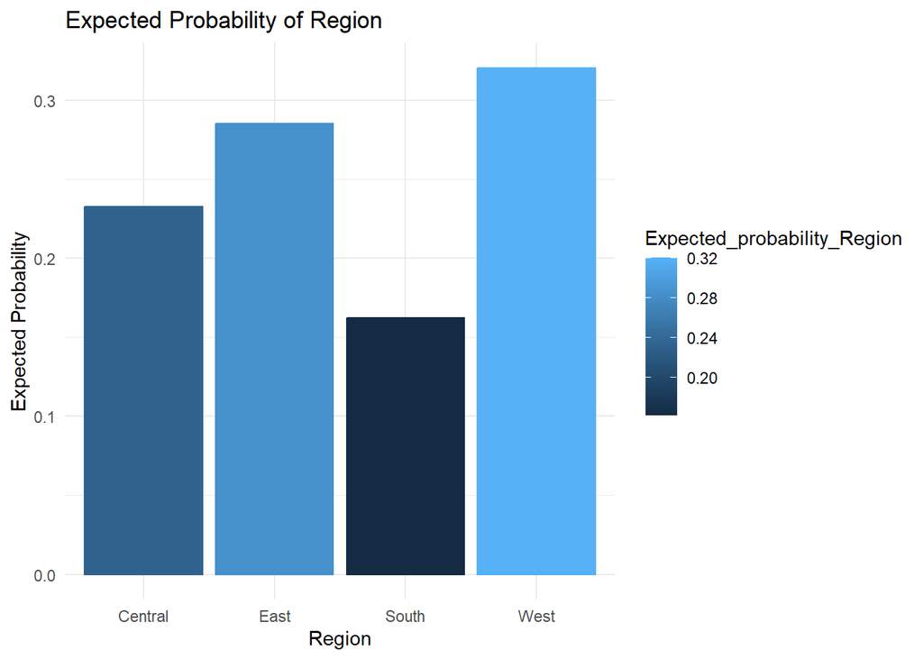

```r
Region_group |>
  ggplot(mapping = aes(x=Region, y = Expected_probability_Region, color=Expected_probability_Region, fill=Expected_probability_Region)) +
  geom_bar(stat = "identity") +
  labs(
    title = "Expected Probability of Region",
    x = "Region",
    y = "Expected Probability"
  ) +
  theme_minimal()
```

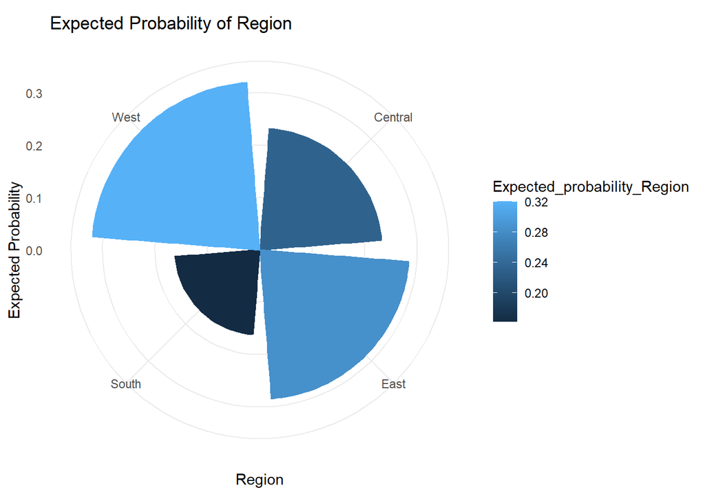

```r
last_plot() +
  coord_polar()
```

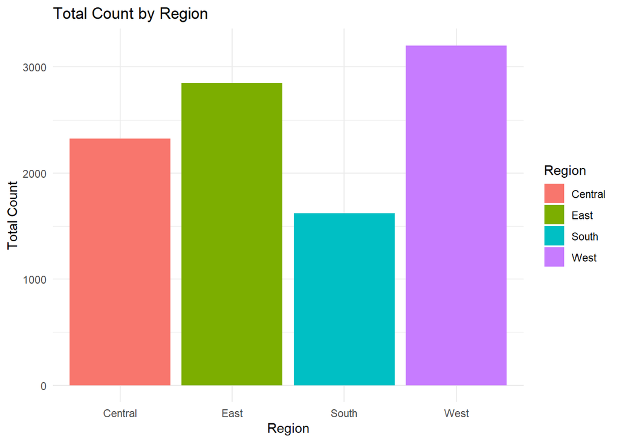

```r
ggplot(Region_group, aes(x = Region, y = total_count_region, fill = Region)) +
  geom_bar(stat = "identity") +
  labs(
    title = "Total Count by Region",
    x = "Region",
    y = "Total Count"
  ) +
  theme_minimal()
```

The observations are seen in the plots above. Most products are bought in the west and East region of US. Followed by Central. South has the least customers with products bought.

###3.Category -

- Expected Probability - Category

```r
# 3 group_by Category
Category_group <- Superstore_data |>
  group_by(Category) |>
  summarise(total_count_category=n(),
            .groups = 'drop') |>
  mutate(Expected_probability_Category= (total_count_category/total_records))

Category_group
```

```
## # A tibble: 3 × 3
##   Category        total_count_category Expected_probability_Category
##   <chr>                          <int>                         <dbl>
## 1 Furniture                       2121                         0.212
## 2 Office Supplies                 6026                         0.603
## 3 Technology                      1847                         0.185
```

```r
merged_data <- merge(Superstore_data, Category_group, by = "Category", all.x = TRUE)

# Define a function to calculate 'Segment_Special_tag'
Category_Special_tag <- function(total_count_category) {
  if (total_count_category >= 1848) {
    return("normal")
  }else {
    return("low")
  }
}

# Apply the function to create 'Segment_anomaly' column
merged_data$Category_Special_tag <- sapply(merged_data$total_count_category, Category_Special_tag)


# Print the resulting table
print(merged_data|> select("Category","Expected_probability_Category","Category_Special_tag")|> sample_n(10))
```

```
##           Category Expected_probability_Category Category_Special_tag
## 1        Furniture                     0.2122273               normal
## 2       Technology                     0.1848109                  low
## 3        Furniture                     0.2122273               normal
## 4        Furniture                     0.2122273               normal
## 5        Furniture                     0.2122273               normal
## 6  Office Supplies                     0.6029618               normal
## 7        Furniture                     0.2122273               normal
## 8  Office Supplies                     0.6029618               normal
## 9       Technology                     0.1848109                  low
## 10 Office Supplies                     0.6029618               normal
```

Observations -  
- 0.6029 is the probability of records in the dataset that have purchased Office Supply products. Following which we can see Furniture at o.2121 and Technology having probability of 0.1847.

- So most products bought in US are Office Supplies as per the record count and probability.

## - To check if we pull a row/data randomly, then which one Category would we observe

#1.

```r
sample1 <- sample_n(merged_data,1)
sample1 |> select("Category","Expected_probability_Category","Category_Special_tag")
```

```
##          Category Expected_probability_Category Category_Special_tag
## 1 Office Supplies                     0.6029618               normal
```

#2.

```r
sample2 <- sample_n(merged_data,1)
sample2 |> select("Category","Expected_probability_Category","Category_Special_tag")
```

```
##          Category Expected_probability_Category Category_Special_tag
## 1 Office Supplies                     0.6029618               normal
```

#3.

```r
sample3 <- sample_n(merged_data,1)
sample3 |> select("Category","Expected_probability_Category","Category_Special_tag")
```

```
##          Category Expected_probability_Category Category_Special_tag
## 1 Office Supplies                     0.6029618               normal
```

#4.

```r
sample4 <- sample_n(merged_data,1)
sample4 |> select("Category","Expected_probability_Category","Category_Special_tag")
```

```
##          Category Expected_probability_Category Category_Special_tag
## 1 Office Supplies                     0.6029618               normal
```

Can see that it is pretty difficult to obtain Technology category when picking randomly as its probability is 0.18

Visualize Category Group -

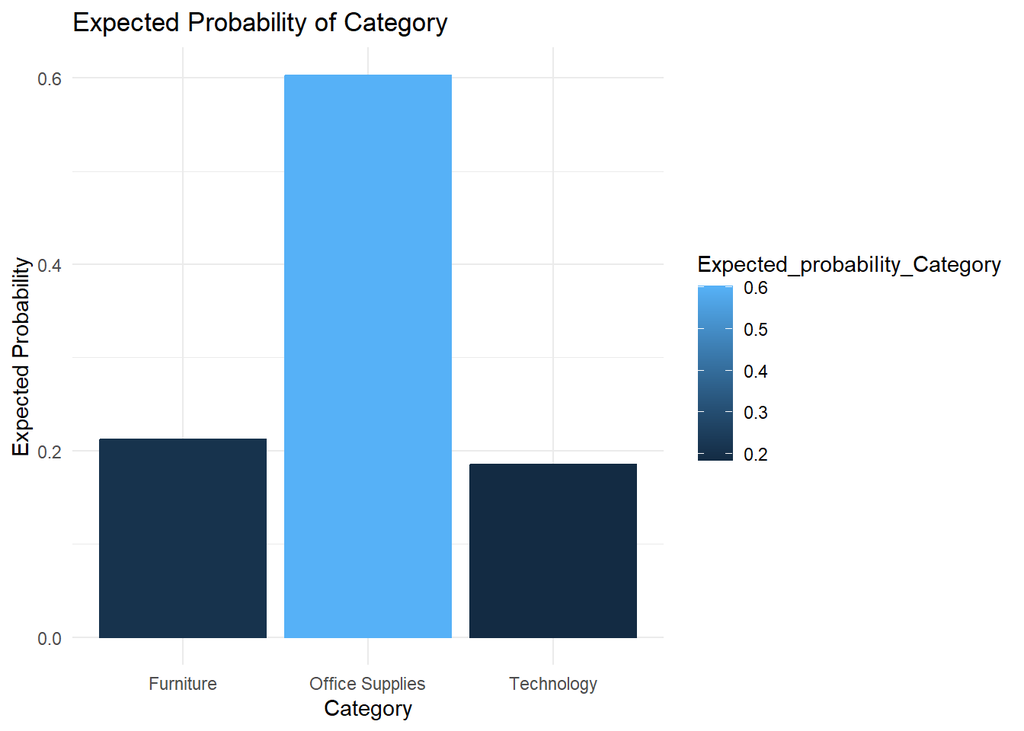

```r
Category_group |>
  ggplot(mapping = aes(x=Category, y = Expected_probability_Category, color=Expected_probability_Category, fill=Expected_probability_Category)) +
  geom_bar(stat = "identity") +
  labs(
    title = "Expected Probability of Category",
    x = "Category",
    y = "Expected Probability"
  ) +
  theme_minimal()
```

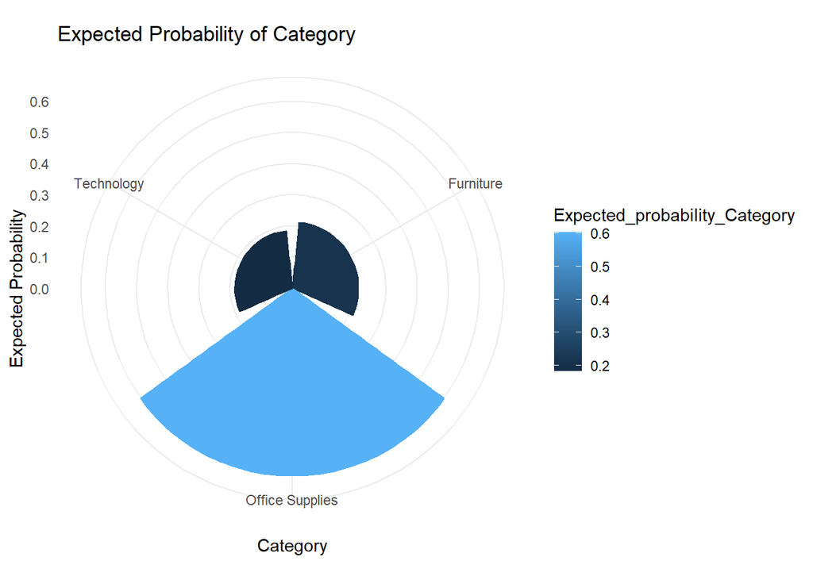

```r
last_plot() +
  coord_polar()
```

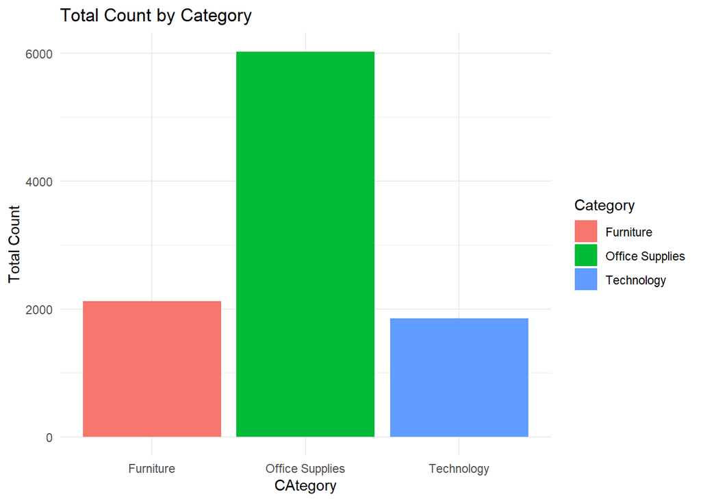

```r
ggplot(Category_group, aes(x = Category, y = total_count_category, fill = Category)) +
  geom_bar(stat = "identity") +
  labs(
    title = "Total Count by Category",
    x = "CAtegory",
    y = "Total Count"
  ) +
  theme_minimal()
```

From the above plot, can state a few things - i. Office Supplies category has the most purchases ii. Furniture and Technology sees the least in Category

4.Sub-Category :

- Expected Probability - Sub-Category

```r
# 4 group_by Category and Region
  Sub_category_group <- Superstore_data |>
  group_by(Sub.Category) |>
  summarise(total_count_sub_category=n(),
            .groups = 'drop') |>
  mutate(Expected_probability_sub_Category=(total_count_sub_category/total_records))

Sub_category_group
```

```
## # A tibble: 17 × 3
##    Sub.Category total_count_sub_category Expected_probability_sub_Category
##    <chr>                           <int>                             <dbl>
##  1 Accessories                       775                           0.0775
##  2 Appliances                        466                           0.0466
##  3 Art                               796                           0.0796
##  4 Binders                          1523                           0.152
##  5 Bookcases                         228                           0.0228
##  6 Chairs                            617                           0.0617
##  7 Copiers                            68                           0.00680
##  8 Envelopes                         254                           0.0254
##  9 Fasteners                         217                           0.0217
## 10 Furnishings                       957                           0.0958
## 11 Labels                            364                           0.0364
## 12 Machines                          115                           0.0115
## 13 Paper                            1370                           0.137
## 14 Phones                            889                           0.0890
## 15 Storage                           846                           0.0847
## 16 Supplies                          190                           0.0190
## 17 Tables                            319                           0.0319
```

Observations -  
* There are about 17 products. Each of those having some varied probabilities on how many were bought by each. With Paper and binders having the most probabilities

- So most products bought in US are Office Supplies as per the record count and probability.

Visualize Sub-category Group -

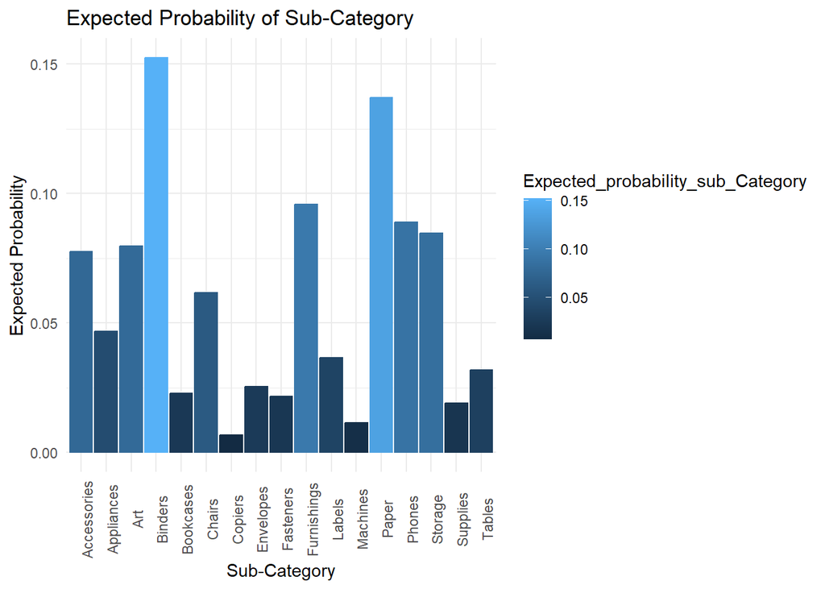

```r
 Sub_category_group|>
  ggplot(mapping = aes(x=Sub.Category, y = Expected_probability_sub_Category, color=Expected_probability_sub_Category, fill=Expected_probability_sub_Category)) +
  geom_bar(stat = "identity") +
  labs(
    title = "Expected Probability of Sub-Category",
    x = "Sub-Category",
    y = "Expected Probability"
  ) +
  theme_minimal()+
   theme (axis.text.x =  element_text(angle=90))
```

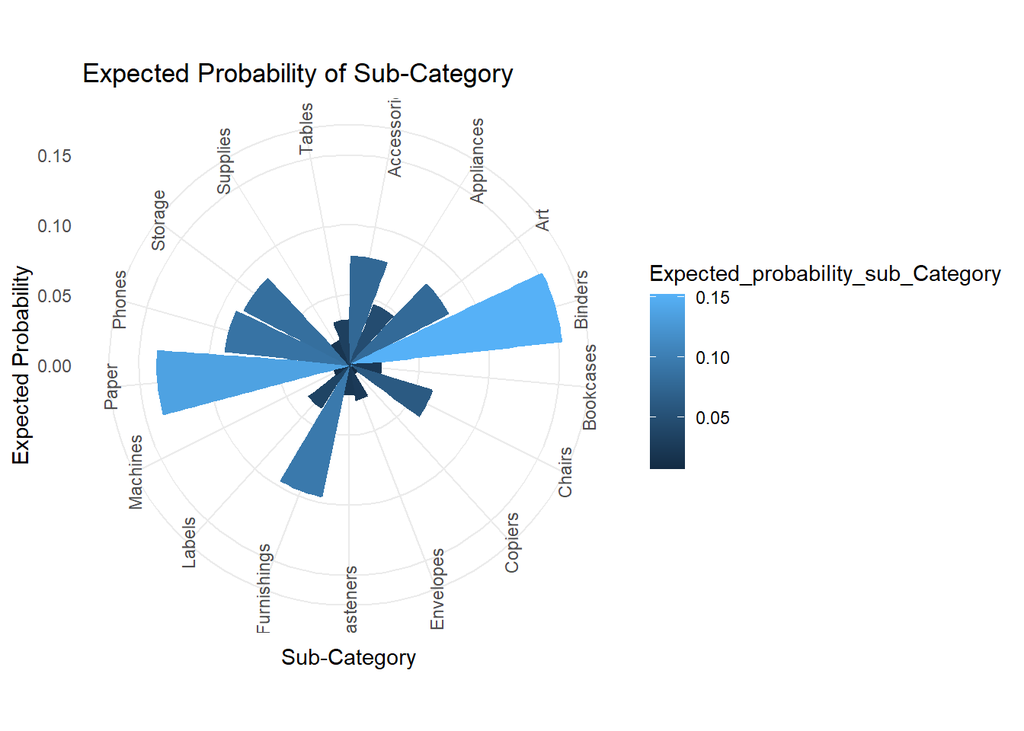

```r
last_plot() +
  coord_polar()
```

**QUESTION**  
## EXTRA assumption and thoughts-

**Pick 2-3 categorical variables for which you know all possible combinations.**  
* Which combinations never show up? Why might that be?  
* Which combinations are the most/least common, and why might that be?  
* Try (i.e., no need if you can’t figure this one out) to find a way to visualize these combinations.

-> There are about 49 states

```r
n_distinct(Superstore_data$State)
```

```
## [1] 49
```

- Top 10 states from where the products are bought -

```r
state_count<- aggregate(Superstore_data$State,by=list(Superstore_data$State), FUN=length)

top_10_states_count <-state_count %>%
arrange(desc(x)) %>%
    slice(1:10) %>%
  rename (
    state=Group.1,
    count=x
  )
top_10_states_count
```

```
##             state count
## 1      California  2001
## 2        New York  1128
## 3           Texas   985
## 4    Pennsylvania   587
## 5      Washington   506
## 6        Illinois   492
## 7            Ohio   469
## 8         Florida   383
## 9        Michigan   255
## 10 North Carolina   249
```

- States which havent or least bought any products -

```r
state_count<- aggregate(Superstore_data$State,by=list(Superstore_data$State), FUN=length)

last_10_states_count <-state_count %>%
arrange(desc(x)) %>%
    tail(10) %>%
  rename (
    state=Group.1,
    count=x
  )
last_10_states_count
```

```
##                   state count
## 40               Kansas    24
## 41                Idaho    21
## 42              Montana    15
## 43         South Dakota    12
## 44              Vermont    11
## 45 District of Columbia    10
## 46                Maine     8
## 47         North Dakota     7
## 48        West Virginia     4
## 49              Wyoming     1
```

Reason for the Wyoming & West Virginia having only 1 and 4 products being purchased, could be that  
–> Maybe there are not much people residing in those regions  
–>or not all records are documented in this dataset, hence the weird observations.

2.Region  
-> There are 4 regions.

```r
n_distinct(Superstore_data$Region)
```

```
## [1] 4
```

-> This covers most of USA.i.e. East, West, Central and South  
-> There is no minimum and max, but with respect to Sales we can figure out which Region has min Sales and max Sales.

```r
aggregate(Superstore_data$Sales, list(Superstore_data$Region), FUN=mean) |>
  rename (
    Region=Group.1,
    Mean_Sales=x
  ) |>
arrange(desc(Mean_Sales))
```

```
##    Region Mean_Sales
## 1   South   241.8036
## 2    East   238.3361
## 3    West   226.4932
## 4 Central   215.7727
```

-> Overall sales is spread around the region. No major max or min in the same.

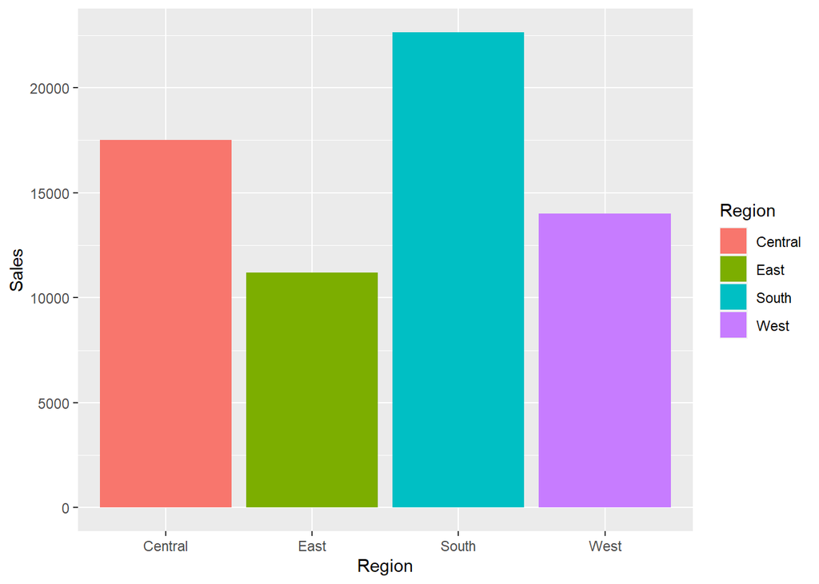

```r
Superstore_data %>%
ggplot() +
  geom_bar(mapping = aes(x = Region, y=Sales,fill = Region),stat = "identity", position="dodge")
```

-> Region vs Category vs Sales:

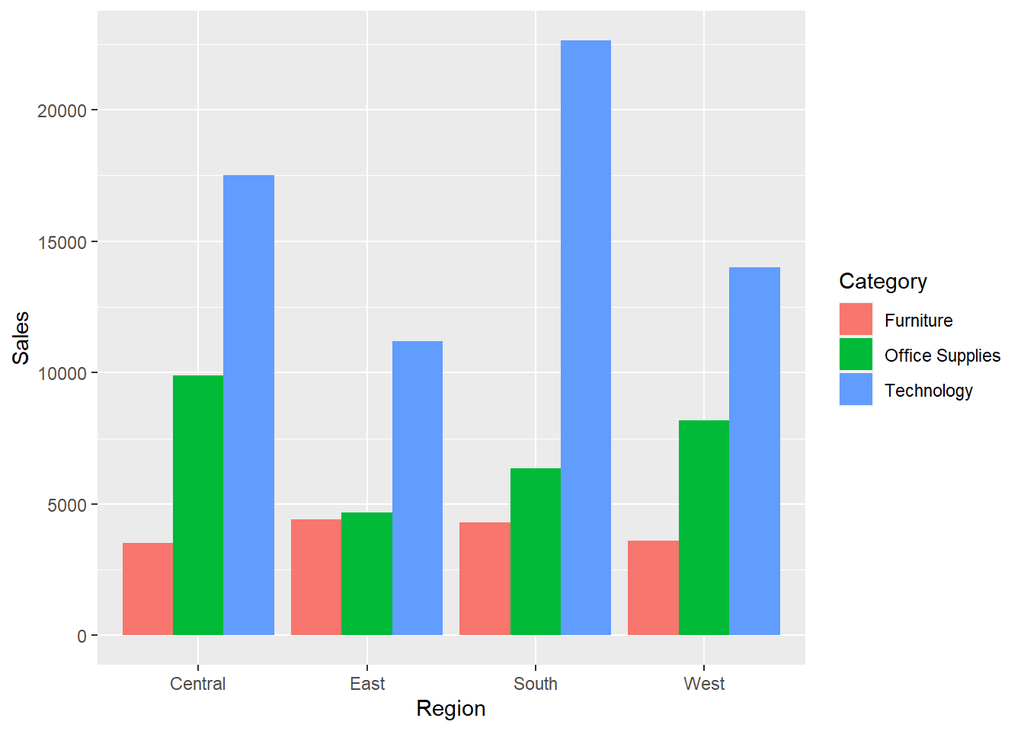

```r
Superstore_data %>%
ggplot() +
  geom_bar(mapping = aes(x = Region, y=Sales,fill = Category),stat = "identity", position="dodge")
```